# Exercícios - ggplot2

O objetivo é recriar os gráficos mostrado abaixo. Não se preocupe se os grafícos não exatamente igual aos apresentados abaixo. O que importa é que todos tenha uma compreensão geral do ggplot2

1. *Histograma*

Para o primeiro gráfico, vamos usar do dataset mpg, que está no pacote do ggplot2

```r
library(ggplot2)
library(ggthemes)
head(mpg)
```

```
## # A tibble: 6 x 11
##   manufacturer model displ  year   cyl      trans   drv   cty   hwy    fl
##          <chr> <chr> <dbl> <int> <int>      <chr> <chr> <int> <int> <chr>
## 1         audi    a4   1.8  1999     4   auto(l5)     f    18    29     p
## 2         audi    a4   1.8  1999     4 manual(m5)     f    21    29     p
## 3         audi    a4   2.0  2008     4 manual(m6)     f    20    31     p
## 4         audi    a4   2.0  2008     4   auto(av)     f    21    30     p
## 5         audi    a4   2.8  1999     6   auto(l5)     f    16    26     p
## 6         audi    a4   2.8  1999     6 manual(m5)     f    18    26     p
## # ... with 1 more variables: class <chr>
```

Vamos agora criar um histograma (**geom_histogram**) da variável *hwy* - horse power dicas: definir o number do barras (bins = ) igual a 20

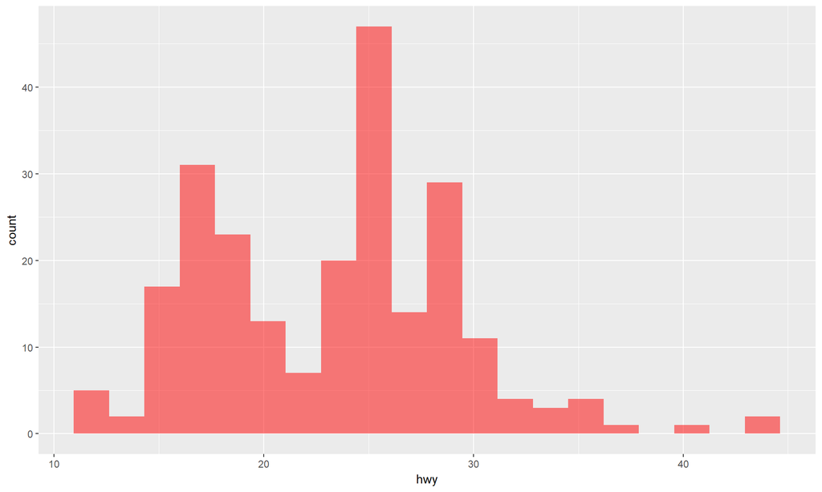

2. *Gráfico de Barra*

Agora vamos faxer um gráfico de barras (**geom_bar**) para mostra o número de marcas (**manufacturer**), sendo o preenchimento das barras será divido pelo o número de cilindros dos carros (**cyl**)

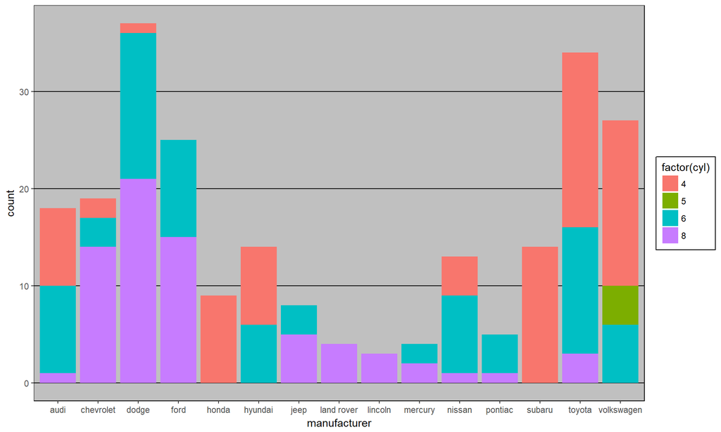

Para esse exercício, vamos utilizar o datasets **txhousing**, que contém informações sobre o Mercado Imobiliário no Texas - EUA

```r
head(txhousing)
```

```
## # A tibble: 6 x 9
##      city  year month sales   volume median listings inventory     date
##     <chr> <int> <int> <dbl>    <dbl>  <dbl>    <dbl>     <dbl>    <dbl>
## 1 Abilene  2000     1    72  5380000  71400      701       6.3 2000.000
## 2 Abilene  2000     2    98  6505000  58700      746       6.6 2000.083
## 3 Abilene  2000     3   130  9285000  58100      784       6.8 2000.167
## 4 Abilene  2000     4    98  9730000  68600      785       6.9 2000.250
## 5 Abilene  2000     5   141 10590000  67300      794       6.8 2000.333
## 6 Abilene  2000     6   156 13910000  66900      780       6.6 2000.417
```

Agora vamos criar um gráfico de pontos -**scatterplot em inglês** das variáveis *sales* e *volume*. Depois vamos brincar com os argumentos *color* e *alpha* no comando **geom_point** para melhor a visualização das informações.

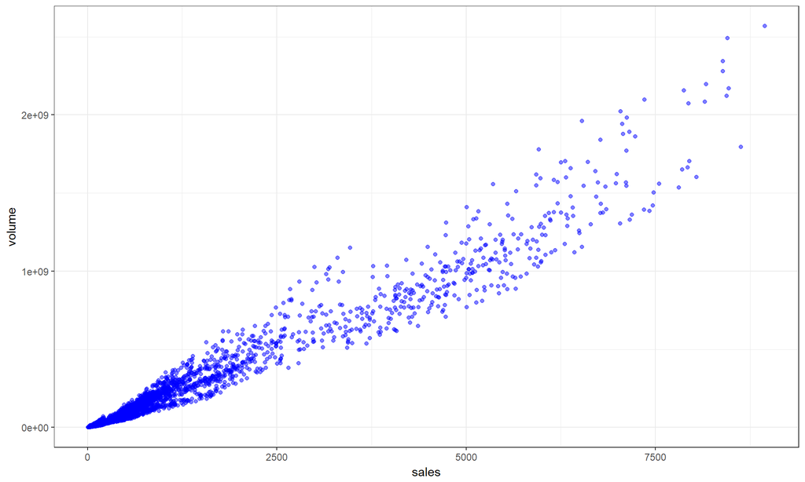

Agora vamos adicionar uma linha de tendência ao nosso gráfico de pontos. *Dica: Procurem pelo comando* **geom_smooth()** *na ajuda do RStudio*

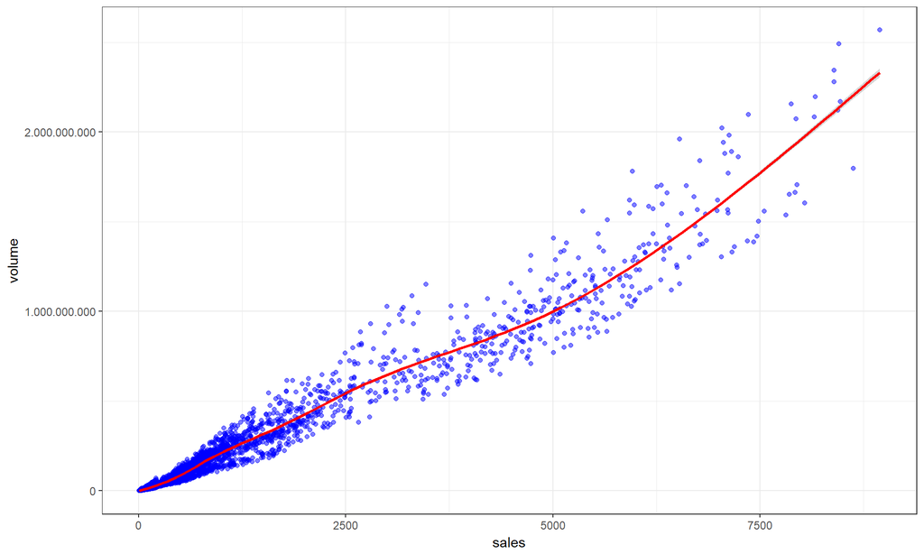

3. *Gráfico de linha*

Utilizando o mesmo dataset do exemplo anterior, vamos plotar o número de vendas (**sales**) segundo o ano das vendas (**year**). Para isso será necessario fazer somar o total das vendas por ano.

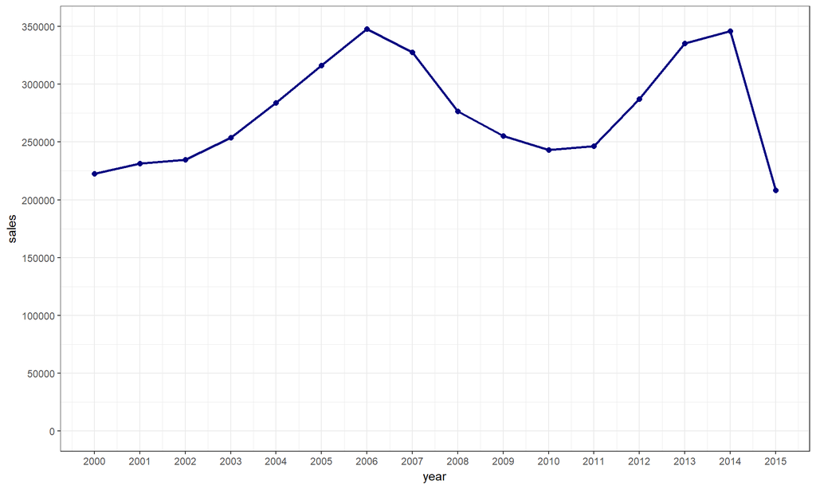